# UNIT 1

### **1. Open Source Software (OSS)**

- **Definition**:
  - Software with publicly accessible source code.
  - Users can view, modify, and distribute the code.
- **Key Characteristics**:
  - **Access to Source Code**: No secrecy; code is open for modification.
  - **Collaboration**: Global developer contributions.
  - **Freedom to Use**: No licensing fees; use for any purpose.
  - **Community Support**: Active user/developer communities.

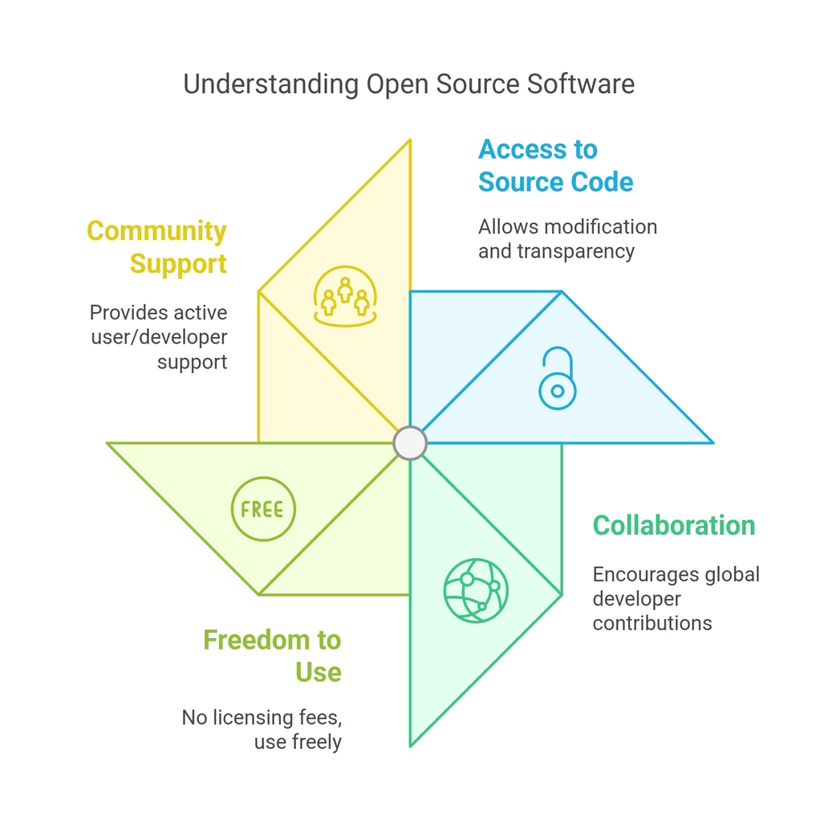

### **2. Examples & Benefits of OSS**

- **Examples**:
  - **Linux OS**: Alternative to Windows/macOS.
  - **Apache HTTP Server**: Popular web server.
  - **Mozilla Firefox**: Web browser.
  - **LibreOffice**: Office suite.
- **Benefits**:
  - **Cost**: Free to use.
  - **Flexibility**: Customizable code.
  - **Security**: Vulnerabilities fixed quickly (many contributors).
  - **Transparency**: Code visibility ensures trust.

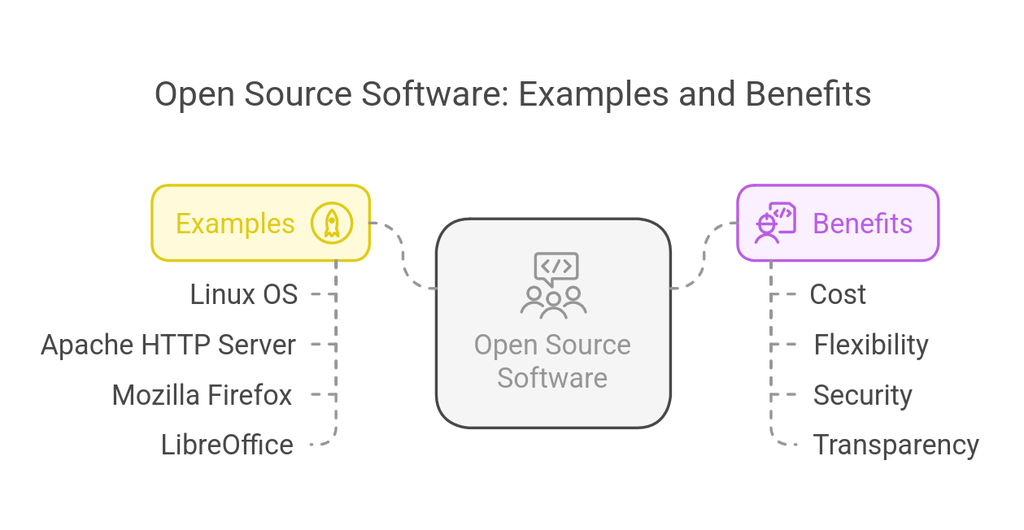

### **3. Development Philosophy of OSS**

- **Principles**:
  - **Collaboration**: Global teamwork (like a “treehouse-building party”).
  - **Transparency**: No hidden code (“no secret recipes”).
  - **Customization**: Modify software freely (like LEGO blocks).
  - **Inclusivity**: All skill levels can contribute (“everyone’s a chef”).
  - **Learning**: Continuous improvement through trial and error (“Build, Break, Learn”).

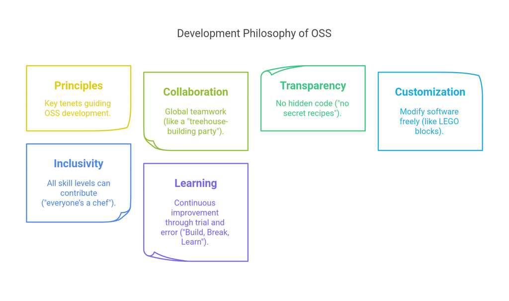

### **4. Pros & Cons of OSS**

| **Pros** | **Cons** |
| --- | --- |
| **Cost-effective** | **Lack of Support** |
| **Community Collaboration** | **Less User-Friendly** |
| **Transparency** | **Compatibility Issues** |
| **Customization** | **Limited Features** |
| **Security** | **Fragmentation** |
| **Freedom** | **Poor Documentation** |

### **5. Open Source vs Closed Source Software**

| **Aspect** | **Open Source** | **Closed Source** |
| --- | --- | --- |
| **Access** | Source code publicly available | Source code proprietary |
| **Cost** | Free | Paid licenses/subscriptions |
| **Development** | Community-driven | Company-controlled team |
| **Examples** | Linux, Apache, Firefox | Windows, Adobe Photoshop |
| **Transparency** | High (code visible) | Low (code hidden) |

### **6. Community Support in OSS**

- **Key Features**:
  - **Collaborative Problem-Solving**: Fix bugs collectively (“solving puzzles as a team”).
  - **Knowledge Sharing**: Forums, documentation, and chat groups.
  - **Continuous Improvement**: Community-driven updates and features.
  - **Support Network**: No need to face issues alone (“group of friends”).

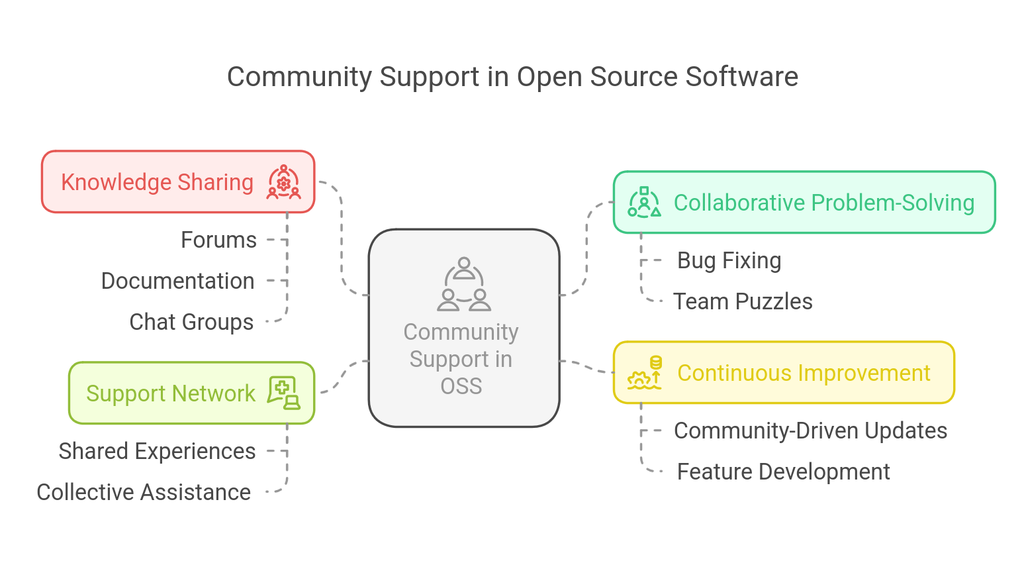

### **7. Websites & Webpages**

- **Website**: Collection of webpages under a domain (e.g., www.example.com).
- **Webpage**: Single HTML document with text/images/videos.
  - **Technologies**: HTML (structure), CSS (styling), JavaScript (interactivity).

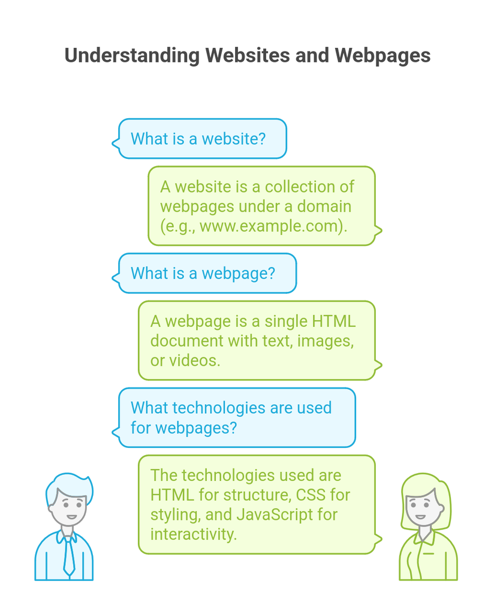

### **8. Static vs Dynamic Websites**

| **Feature** | **Static** | **Dynamic** |
| --- | --- | --- |
| **Content** | Fixed, manually updated HTML | Generated on-the-fly (PHP, Python) |
| **Loading Time** | Faster (pre-built) | Slower (server processing) |
| **Flexibility** | Low (requires coding for changes) | High (CMS integration) |
| **Example** | Small business site | Social media (Facebook, Twitter) |

### **9. Client-Side vs Server-Side Scripting**

| **Aspect** | **Client-Side** | **Server-Side** |
| --- | --- | --- |
| **Location** | Runs on user’s browser | Runs on web server |
| **Languages** | JavaScript, HTML, CSS | PHP, Python, Ruby, Node.js |
| **Function** | DOM manipulation, form validation | Database operations, user auth |
| **Example** | Button click animation | User login authentication |

### **10. Web Hosting Types**

| **Type** | **Description** | **Pros** | **Cons** |
| --- | --- | --- | --- |
| **Shared** | Multiple sites on one server | Cost-effective | Limited resources |
| **Cloud** | Uses interconnected servers | Scalable, reliable | Variable costs |
| **VPS** | Virtual private server | More control, better performance | Costlier than shared |
| **Dedicated** | Entire server for one user | Full control, high performance | Expensive, needs expertise |